# Series

Author

Affiliation

[José Bayoán Santiago Calderón, PhD](https://www.bea.gov)

Bureau of Economic Analysis

Published

2026-03-09

Abstract

This script uses a modified version of the OEWS tables to estimate the share of compensation of employees by industry and year are attributed to various occupation groups. For the occupation groups, we use estimated time-use factors related to gross fixed capital formation of data and database assets. These involvement rates come from the BEA-developed estimates using Lighcast online job, O*NET, and NCSES data. Lastly, we use BEA industry tables to estimate a full-production cost adjustment factor to obtain nominal investment in own account data and database assets.

Keywords

Sum of cost, Own account, IPPs

We start by instantiating the environment.

```julia
const DIR_PRJ = string(strip(read(`git rev-parse --show-toplevel`, String)))
using Pkg
Pkg.activate(DIR_PRJ)
# Pkg.instantiate()
```

```
  Activating project at `/workspaces/Toward-Experimental-Economic-Statistics-on-Own-Account-Data-and-Databases`
```

We load the packages to be used in the script.

```julia
using Base: Fix2
using CSV, DataFrames, TidierData
using StatFiles
using Arrow
using ExcelFiles: ExcelFiles, openxl, readxl, load
using XLSX: XLSX, readtable
using HTTP: HTTP, URI, request
using unzip_jll: unzip
using Impute
using CairoMakie
using CairoMakie: RGB, Colors.distinguishable_colors
using AlgebraOfGraphics
set_aog_theme!()
```

[output not shown]

# R&D

We first get the National Survey of College Graduates ([NSCG](https://ncses.nsf.gov/explore-data/microdata/national-survey-college-graduates)) Public Use Data Files.

```julia
isdir(joinpath(DIR_PRJ, "data", "ncses")) || mkdir(joinpath(DIR_PRJ, "data", "ncses"))
if !isfile(joinpath(DIR_PRJ, "data", "ncses", "college_grads_2021.zip"))
    infile = joinpath(DIR_PRJ, "data", "ncses", "college_grads_2021.zip")
    response = request(
        "GET",
        URI(
            scheme = "https",
            host = "ncses.nsf.gov",
            path = "/822/assets/0/files/college_grads_2021.zip"
        )
    )
    write(infile, response.body)
    dir = dirname(infile)
    run(`$(unzip()) $infile -d $dir`)
end
```

You can read the data and right it to a format which is easier to load.

```julia
# begin
#     x = load(
#       joinpath(DIR_PRJ, "data", "ncses", "pcg21Public", "epcg21.sas7bdat")
#     )
#     y = DataFrame(x)
#     Arrow.write(
#       joinpath(DIR_PRJ, "data", "ncses", "nscg21.arrow"),
#       y
#     )
# end
```

```julia
# ncses_occ = @chain CSV.read(
#     joinpath(DIR_PRJ, "data", "provided", "N3OCPR.tsv"),
#     DataFrame
# ) begin
#     dropmissing!
# end
```

We read the public data files for the NSCG 2021.

```julia
# nscg21 = DataFrame(Arrow.Table(joinpath(DIR_PRJ, "data", "ncses", "nscg21.arrow")))
```

We compute the share of employees per occupation that their primary role is R&D.

```julia
# nscg21_ = @chain nscg21 begin
#     @select(
#         wgt = WTSURVY,
#         occ = as_integer(N3OCPR),
#         primary = WAPRSM,
#         secondary = WASCSM,
#         software10 = WACOM
#     )
#     @group_by(
#         occ, primary, secondary, software10
#     )
#     @summarize(
#         wgt = sum(wgt)
#     )
#     @ungroup
#     @group_by(occ)
#     combine(_) do subdf
#         primary_rnd = @chain subdf begin
#             @select(wgt, primary)
#             dropmissing!
#             @mutate(
#                 mostly_rnd = if_else(primary == "1", "rnd", "not_rnd")
#             )
#             @group_by(mostly_rnd)
#             @summarize(wgt = sum(wgt))
#             @pivot_wider(names_from = mostly_rnd, values_from = wgt)
#         end
#         output_rnd = if "rnd" ∉ names(primary_rnd)
#             DataFrame(rnd=0)
#         elseif "not_rnd" ∉ names(primary_rnd)
#             DataFrame(rnd=1)
#         else
#             @chain primary_rnd begin
#                 @select(rnd = round(rnd / (rnd + not_rnd), digits=4))
#                 dropmissing!
#             end
#         end
#         software = @chain subdf begin
#             @select(wgt, software10)
#             dropmissing!
#             @mutate(
#                 software10 = if_else(software10 == "Y", "software", "not_software")
#             )
#             @group_by(software10)
#             @summarize(wgt = sum(wgt))
#             @pivot_wider(names_from = software10, values_from = wgt)
#         end
#         output_software = if "software" ∉ names(software)
#             DataFrame(software=0)
#         elseif "not_software" ∉ names(software)
#             DataFrame(software=1)
#         else
#             @chain software begin
#                 @select(software = round(software / (software + not_software), digits=2))
#                 dropmissing!
#             end
#         end
#         output = @chain output_rnd begin
#             @bind_cols(output_software)
#         end
#     end
#     dropmissing!
#     @inner_join(ncses_occ)
#     @arrange(occ)
# end
```

```julia
# nscg21__ = @chain nscg21_ begin
#     @group_by(component)
#     @summarize(
#         rnd = round(mean(rnd), digits = 4),
#         software = round(mean(software), digits = 4)
#     )
# end
# CSV.write(
#     joinpath(DIR_PRJ, "data", "ncses", "nscg21.tsv"),
#     nscg21__,
#     delim = '\t'
# )
```

```julia
nscg21_ = CSV.read(joinpath(DIR_PRJ, "data", "ncses", "nscg21.tsv"), DataFrame)
```

108×3 DataFrame

83 rows omitted

| Row | component String | rnd Float64 | software Float64 |
| --- | --- | --- | --- |
| 1 | 15-1221 | 0.4901 | 0.88 |
| 2 | 15-1212 \| 15-1241 \| 15-1254 | 0.1943 | 0.7267 |
| 3 | 15-1231 \| 15-1232 | 0.138 | 0.54 |
| 4 | 15-1211 | 0.1781 | 0.79 |
| 5 | 15-1242 \| 15-1243 | 0.1058 | 0.74 |
| 6 | 15-1244 | 0.2042 | 0.75 |
| 7 | 15-1252 | 0.1137 | 0.95 |
| 8 | 15-2021 | 0.5616 | 0.34 |
| 9 | 15-2031 | 0.4086 | 0.55 |
| 10 | 15-2041 | 0.6164 | 0.78 |
| 11 | 19-4012 \| 19-4013 | 0.6509 | 0.15 |
| 12 | 19-1021 | 0.8067 | 0.21 |
| 13 | 19-1023 | 0.6857 | 0.19 |
| ⋮ | ⋮ | ⋮ | ⋮ |
| 97 | 43-9022 | 0.0263 | 0.09 |
| 98 | 23-1011 | 0.0184 | 0.03 |
| 99 | 23-1012 | 0.0184 | 0.03 |
| 100 | 23-1021 | 0.0184 | 0.03 |
| 101 | 23-1022 | 0.0184 | 0.03 |
| 102 | 23-1023 | 0.0184 | 0.03 |
| 103 | 23-2011 | 0.0184 | 0.03 |
| 104 | 25-4011 | 0.1659 | 0.15 |
| 105 | 25-4012 | 0.1659 | 0.15 |
| 106 | 25-4013 | 0.1659 | 0.15 |
| 107 | 25-4022 | 0.1659 | 0.15 |
| 108 | 25-4031 | 0.1659 | 0.15 |

# Employment and Wages

Read the employment and wages files by components.

```julia
oews_timeseries = @chain CSV.read(
    joinpath(DIR_PRJ, "data", "oews", "timeseries_02_12.tsv"),
    DataFrame
    ) begin
    @bind_rows(
        CSV.read(
            joinpath(DIR_PRJ, "data", "oews", "timeseries_13_24.tsv"),
            DataFrame
        )
    )
end
```

1095947×8 DataFrame

1095922 rows omitted

| Row | component String | naics Int64 | own Int64 | year Int64 | tot_emp Int64 | h_mean Float64 | payroll Int64 | occ_ttl String |
| --- | --- | --- | --- | --- | --- | --- | --- | --- |
| 1 | 11-1011 | 1133 | 0 | 2002 | 310 | 43.52 | 13491 | Chief Executives |
| 2 | 11-1011 | 1151 | 0 | 2002 | 690 | 51.84 | 35770 | Chief Executives |
| 3 | 11-1011 | 1152 | 0 | 2002 | 80 | 48.36 | 3869 | Chief Executives |
| 4 | 11-1011 | 2111 | 0 | 2002 | 730 | 84.14 | 61422 | Chief Executives |
| 5 | 11-1011 | 2121 | 0 | 2002 | 230 | 64.46 | 14826 | Chief Executives |
| 6 | 11-1011 | 2123 | 0 | 2002 | 330 | 63.62 | 20995 | Chief Executives |
| 7 | 11-1011 | 2131 | 0 | 2002 | 900 | 72.6 | 65340 | Chief Executives |
| 8 | 11-1011 | 2211 | 0 | 2002 | 1270 | 75.52 | 95910 | Chief Executives |
| 9 | 11-1011 | 2212 | 0 | 2002 | 510 | 74.48 | 37985 | Chief Executives |
| 10 | 11-1011 | 2213 | 0 | 2002 | 260 | 54.44 | 14154 | Chief Executives |
| 11 | 11-1011 | 2361 | 0 | 2002 | 5400 | 68.66 | 370764 | Chief Executives |
| 12 | 11-1011 | 2362 | 0 | 2002 | 5590 | 65.39 | 365530 | Chief Executives |
| 13 | 11-1011 | 2371 | 0 | 2002 | 2030 | 61.52 | 124886 | Chief Executives |
| ⋮ | ⋮ | ⋮ | ⋮ | ⋮ | ⋮ | ⋮ | ⋮ | ⋮ |
| 1095936 | 53-7121 | 4245 | 0 | 2024 | 220 | 20.35 | 4477 | Tank Car, Truck, and Ship Loaders |
| 1095937 | 53-7121 | 4830 | 0 | 2024 | 1690 | 36.3 | 61347 | Tank Car, Truck, and Ship Loaders |
| 1095938 | 53-7121 | 4831 | 0 | 2024 | 60 | 28.71 | 1723 | Tank Car, Truck, and Ship Loaders |
| 1095939 | 53-7121 | 4832 | 0 | 2024 | 1640 | 36.57 | 59975 | Tank Car, Truck, and Ship Loaders |
| 1095940 | 53-7121 | 4840 | 0 | 2024 | 250 | 21.95 | 5488 | Tank Car, Truck, and Ship Loaders |
| 1095941 | 53-7121 | 4880 | 0 | 2024 | 3650 | 29.42 | 107383 | Tank Car, Truck, and Ship Loaders |
| 1095942 | 53-7121 | 4882 | 0 | 2024 | 1190 | 29.59 | 35212 | Tank Car, Truck, and Ship Loaders |
| 1095943 | 53-7121 | 4883 | 0 | 2024 | 2440 | 29.44 | 71834 | Tank Car, Truck, and Ship Loaders |
| 1095944 | 53-7121 | 4930 | 0 | 2024 | 600 | 26.92 | 16152 | Tank Car, Truck, and Ship Loaders |
| 1095945 | 53-7121 | 4931 | 0 | 2024 | 600 | 26.92 | 16152 | Tank Car, Truck, and Ship Loaders |
| 1095946 | 53-7121 | 5610 | 0 | 2024 | 290 | 21.7 | 6293 | Tank Car, Truck, and Ship Loaders |
| 1095947 | 53-7121 | 5613 | 0 | 2024 | 220 | 19.26 | 4237 | Tank Car, Truck, and Ship Loaders |

Obtain the crosswalk file from SOC 2018 to the components.

```julia
soc_socs = @chain oews_timeseries begin
    @select(component)
    @distinct
    @group_by(component)
    combine(_) do subdf
        DataFrame(soc18 = split(only(subdf.component), " | "))
    end
end
```

735×2 DataFrame

710 rows omitted

| Row | component String | soc18 SubStrin… |
| --- | --- | --- |
| 1 | 11-1011 | 11-1011 |
| 2 | 11-1021 | 11-1021 |
| 3 | 11-2011 | 11-2011 |
| 4 | 11-2021 | 11-2021 |
| 5 | 11-2022 | 11-2022 |
| 6 | 11-2032 \| 11-2033 | 11-2032 |
| 7 | 11-2032 \| 11-2033 | 11-2033 |
| 8 | 11-3012 \| 11-3013 | 11-3012 |
| 9 | 11-3012 \| 11-3013 | 11-3013 |
| 10 | 11-3021 | 11-3021 |
| 11 | 11-3031 | 11-3031 |
| 12 | 11-3051 | 11-3051 |
| 13 | 11-3061 | 11-3061 |
| ⋮ | ⋮ | ⋮ |
| 724 | 47-2131 | 47-2131 |
| 725 | 47-2132 | 47-2132 |
| 726 | 49-9081 \| 49-9099 | 49-9081 |
| 727 | 49-9081 \| 49-9099 | 49-9099 |
| 728 | 53-6032 \| 53-6099 | 53-6032 |
| 729 | 53-6032 \| 53-6099 | 53-6099 |
| 730 | 29-1024 | 29-1024 |
| 731 | 21-1094 \| 21-1099 | 21-1094 |
| 732 | 21-1094 \| 21-1099 | 21-1099 |
| 733 | 33-9093 | 33-9093 |
| 734 | 25-3031 | 25-3031 |
| 735 | 25-3041 | 25-3041 |

From SOC 2018 we map those to the employment and wages components.

```julia
components = @chain oews_timeseries begin
    @select(component)
    @distinct
    @group_by(component)
    @summarize(soc18 = split(~only(component), " | "))
end
```

735×2 DataFrame

710 rows omitted

| Row | component String | soc18 SubStrin… |
| --- | --- | --- |
| 1 | 11-1011 | 11-1011 |
| 2 | 11-1021 | 11-1021 |
| 3 | 11-2011 | 11-2011 |
| 4 | 11-2021 | 11-2021 |
| 5 | 11-2022 | 11-2022 |
| 6 | 11-2032 \| 11-2033 | 11-2032 |
| 7 | 11-2032 \| 11-2033 | 11-2033 |
| 8 | 11-3012 \| 11-3013 | 11-3012 |
| 9 | 11-3012 \| 11-3013 | 11-3013 |
| 10 | 11-3021 | 11-3021 |
| 11 | 11-3031 | 11-3031 |
| 12 | 11-3051 | 11-3051 |
| 13 | 11-3061 | 11-3061 |
| ⋮ | ⋮ | ⋮ |
| 724 | 47-2131 | 47-2131 |
| 725 | 47-2132 | 47-2132 |
| 726 | 49-9081 \| 49-9099 | 49-9081 |
| 727 | 49-9081 \| 49-9099 | 49-9099 |
| 728 | 53-6032 \| 53-6099 | 53-6032 |
| 729 | 53-6032 \| 53-6099 | 53-6099 |
| 730 | 29-1024 | 29-1024 |
| 731 | 21-1094 \| 21-1099 | 21-1094 |
| 732 | 21-1094 \| 21-1099 | 21-1099 |
| 733 | 33-9093 | 33-9093 |
| 734 | 25-3031 | 25-3031 |
| 735 | 25-3041 | 25-3041 |

```julia
component_ttl = @chain oews_timeseries begin
    @arrange(desc(year))
    @select(component, occ_ttl)
    @distinct(component)
end
```

667×2 DataFrame

642 rows omitted

| Row | component String | occ_ttl String |
| --- | --- | --- |
| 1 | 11-1011 | Chief Executives |
| 2 | 11-1021 | General and Operations Managers |
| 3 | 11-2011 | Advertising and Promotions Managers |
| 4 | 11-2021 | Marketing Managers |
| 5 | 11-2022 | Sales Managers |
| 6 | 11-2032 \| 11-2033 | Public Relations and Fundraising Managers |
| 7 | 11-3012 \| 11-3013 | Administrative Services and Facilities Managers |
| 8 | 11-3021 | Computer and Information Systems Managers |
| 9 | 11-3031 | Financial Managers |
| 10 | 11-3051 | Industrial Production Managers |
| 11 | 11-3061 | Purchasing Managers |
| 12 | 11-3071 | Transportation, Storage, and Distribution Managers |
| 13 | 11-3111 | Compensation and Benefits Managers |
| ⋮ | ⋮ | ⋮ |
| 656 | 53-7051 | Industrial Truck and Tractor Operators |
| 657 | 53-7061 | Cleaners of Vehicles and Equipment |
| 658 | 53-7062 | Laborers and Freight, Stock, and Material Movers, Hand |
| 659 | 53-7063 | Machine Feeders and Offbearers |
| 660 | 53-7064 | Packers and Packagers, Hand |
| 661 | 53-7065 | Stockers and Order Fillers |
| 662 | 53-7071 | Gas Compressor and Gas Pumping Station Operators |
| 663 | 53-7072 | Pump Operators, Except Wellhead Pumpers |
| 664 | 53-7073 | Wellhead Pumpers |
| 665 | 53-7081 | Refuse and Recyclable Material Collectors |
| 666 | 53-7121 | Tank Car, Truck, and Ship Loaders |
| 667 | 39-1014 | First-Line Supervisors of Personal Service and Entertainment and Recreation Workers, Except Gambling Services |

```julia
CSV.write(
    joinpath(DIR_PRJ, "data", "components_ttl.tsv"),
    component_ttl,
    delim = '\t'
)
```

```
"/workspaces/Toward-Experimental-Economic-Statistics-on-Own-Account-Data-and-Databases/data/components_ttl.tsv"
```

# BEA

We first obtain the share of job openings with some skill identified as relevant to data activities by component.

```julia
lightcast = @chain CSV.read(
    joinpath(DIR_PRJ, "data", "provided",  "job_ads.tsv"),
    DataFrame,
) begin
    @right_join(
        @chain oews_timeseries begin
            @select(component, year)
            @arrange(component, desc(year))
            @select(-year)
            @distinct(component)
        end
    )
    @mutate(lightcast = coalesce(5as_integer(round(100lightcast) / 5), 0))
    @mutate(lightcast = if_else(lightcast < 10, 0, lightcast))
end
```

667×2 DataFrame

642 rows omitted

| Row | component String | lightcast Int64 |
| --- | --- | --- |
| 1 | 11-1011 | 10 |
| 2 | 11-1021 | 0 |
| 3 | 11-2011 | 0 |
| 4 | 11-2021 | 0 |
| 5 | 11-2022 | 0 |
| 6 | 11-2032 \| 11-2033 | 0 |
| 7 | 11-3012 \| 11-3013 | 15 |
| 8 | 11-3021 | 25 |
| 9 | 11-3031 | 15 |
| 10 | 11-3051 | 10 |
| 11 | 11-3061 | 10 |
| 12 | 11-3071 | 10 |
| 13 | 11-3111 | 25 |
| ⋮ | ⋮ | ⋮ |
| 656 | 29-2036 \| 29-2057 \| 29-2072 \| 29-2092 \| 29-2099 | 0 |
| 657 | 29-9092 \| 29-9093 \| 29-9099 | 0 |
| 658 | 39-1014 | 0 |
| 659 | 39-4012 \| 39-9099 | 0 |
| 660 | 39-5093 | 0 |
| 661 | 47-2022 | 0 |
| 662 | 47-2142 | 0 |
| 663 | 47-5011 | 0 |
| 664 | 47-5023 | 0 |
| 665 | 51-7032 | 0 |
| 666 | 53-3051 \| 53-3053 \| 53-3054 | 0 |
| 667 | 53-7073 | 0 |

We also include a curated list based on O*NET (U.S. Department of Labor 2024) and the Occupational Outlook Handbook (Bureau of Labor Statistics 2024) that restricts occupations to those within a scope/work context which indicates a probable active contribution to data asset formation through their primary work activities.

```julia
probable = @chain CSV.read(
    joinpath(DIR_PRJ, "data", "provided", "probable.tsv"),
    DataFrame
) begin
    @left_join(@select(nscg21_, component, rnd, software))
    @mutate(
        rnd = 5as_integer(round(coalesce(100rnd, 0) / 5)),
        software = 5as_integer(round(coalesce(100software, 0) / 5))
    )
end
```

717×4 DataFrame

692 rows omitted

| Row | component String | probable Bool | rnd Int64 | software Int64 |
| --- | --- | --- | --- | --- |
| 1 | 11-3021 | false | 5 | 65 |
| 2 | 11-9111 | false | 0 | 5 |
| 3 | 11-9121 | false | 20 | 10 |
| 4 | 13-1141 | false | 5 | 10 |
| 5 | 13-1151 | false | 5 | 10 |
| 6 | 13-2011 | true | 5 | 15 |
| 7 | 13-2053 | false | 5 | 10 |
| 8 | 15-1211 | false | 20 | 80 |
| 9 | 15-1221 | false | 50 | 90 |
| 10 | 15-1244 | false | 20 | 75 |
| 11 | 15-1251 | false | 10 | 95 |
| 12 | 15-2011 | true | 20 | 50 |
| 13 | 15-2021 | false | 55 | 35 |
| ⋮ | ⋮ | ⋮ | ⋮ | ⋮ |
| 706 | 31-1121 \| 31-1122 | false | 0 | 0 |
| 707 | 31-1131 \| 31-1132 | false | 0 | 0 |
| 708 | 31-9097 \| 31-9099 | false | 0 | 0 |
| 709 | 33-1091 \| 33-1099 | false | 0 | 0 |
| 710 | 33-9094 \| 33-9099 | false | 0 | 0 |
| 711 | 47-2231 \| 47-4091 \| 47-4099 | false | 0 | 0 |
| 712 | 49-9081 \| 49-9099 | false | 0 | 0 |
| 713 | 51-2022 \| 51-2023 | false | 0 | 0 |
| 714 | 51-2092 \| 51-2099 | false | 0 | 0 |
| 715 | 53-1042 \| 53-1043 \| 53-1044 \| 53-1049 | false | 0 | 0 |
| 716 | 53-3051 \| 53-3054 | false | 0 | 0 |
| 717 | 53-6032 \| 53-6099 | false | 0 | 0 |

We also include the involvement rates used by own account software.

```julia
oas = CSV.read(
    joinpath(DIR_PRJ, "data", "provided", "oas.tsv"),
    DataFrame
)
```

6×2 DataFrame

| Row | component String | oas Int64 |
| --- | --- | --- |
| 1 | 15-1251 \| 15-2099 | 10 |
| 2 | 15-1252 \| 15-1253 | 75 |
| 3 | 15-1212 \| 15-1241 \| 15-1254 \| 15-1255 | 85 |
| 4 | 15-1244 | 15 |
| 5 | 15-1211 | 75 |
| 6 | 15-1221 | 25 |

The final involvement rates are rounded to the nearest factor of 5 within 10 to 90 and reflect the rate based on the online job data adjusted to account for R&D and OAS.

```julia
component_rates = @chain lightcast begin
    @left_join(probable)
    @left_join(oas)
    @mutate(refined = if_else(probable, 5as_integer(round(lightcast * (1 - rnd / 100) / 5)), 0))
    @mutate(refined = # Adjustment for software
        if_else(!ismissing(oas), 5as_integer(round(refined * (1 - oas / 100 / 2) / 5)), refined)
    )
    @mutate(refined = case_when(
        refined < 10 => 0,
        refined > 90 => 90,
        true => refined
    ))
    select(Not([:rnd, :software, :probable, :oas]))
    dropmissing!
    @inner_join(component_ttl)
    @distinct
end
```

649×4 DataFrame

624 rows omitted

| Row | component String | lightcast Int64 | refined Int64 | occ_ttl String |
| --- | --- | --- | --- | --- |
| 1 | 11-1011 | 10 | 0 | Chief Executives |
| 2 | 11-1021 | 0 | 0 | General and Operations Managers |
| 3 | 11-2011 | 0 | 0 | Advertising and Promotions Managers |
| 4 | 11-2021 | 0 | 0 | Marketing Managers |
| 5 | 11-2022 | 0 | 0 | Sales Managers |
| 6 | 11-2032 \| 11-2033 | 0 | 0 | Public Relations and Fundraising Managers |
| 7 | 11-3012 \| 11-3013 | 15 | 0 | Administrative Services and Facilities Managers |
| 8 | 11-3021 | 25 | 0 | Computer and Information Systems Managers |
| 9 | 11-3031 | 15 | 15 | Financial Managers |
| 10 | 11-3051 | 10 | 10 | Industrial Production Managers |
| 11 | 11-3061 | 10 | 0 | Purchasing Managers |
| 12 | 11-3071 | 10 | 0 | Transportation, Storage, and Distribution Managers |
| 13 | 11-3111 | 25 | 0 | Compensation and Benefits Managers |
| ⋮ | ⋮ | ⋮ | ⋮ | ⋮ |
| 638 | 53-7041 | 0 | 0 | Hoist and Winch Operators |
| 639 | 53-7051 | 0 | 0 | Industrial Truck and Tractor Operators |
| 640 | 53-7061 | 0 | 0 | Cleaners of Vehicles and Equipment |
| 641 | 53-7062 | 0 | 0 | Laborers and Freight, Stock, and Material Movers, Hand |
| 642 | 53-7063 | 0 | 0 | Machine Feeders and Offbearers |
| 643 | 53-7064 | 0 | 0 | Packers and Packagers, Hand |
| 644 | 53-7065 | 0 | 0 | Stockers and Order Fillers |
| 645 | 53-7071 | 0 | 0 | Gas Compressor and Gas Pumping Station Operators |
| 646 | 53-7072 | 15 | 0 | Pump Operators, Except Wellhead Pumpers |
| 647 | 53-7073 | 0 | 0 | Wellhead Pumpers |
| 648 | 53-7081 | 15 | 0 | Refuse and Recyclable Material Collectors |
| 649 | 53-7121 | 0 | 0 | Tank Car, Truck, and Ship Loaders |

We save the component rates file.

```julia
CSV.write(
    joinpath(DIR_PRJ, "data", "occ_lightcast_refined.tsv"),
    component_rates,
    delim = '\t'
)
```

```
"/workspaces/Toward-Experimental-Economic-Statistics-on-Own-Account-Data-and-Databases/data/occ_lightcast_refined.tsv"
```

# Labor Costs

We use a premade mapping of NAICS3/4 to the integrated production accounts at various levels.

```julia
naics2ipa = CSV.read(
    joinpath(DIR_PRJ, "data", "provided", "naics2ipa.tsv"),
    DataFrame
)
```

116×6 DataFrame

91 rows omitted

| Row | naics Int64 | naics_title String | account String7 | aggregate String7 | description String | production_account String |
| --- | --- | --- | --- | --- | --- | --- |
| 1 | 1130 | Forestry and Logging | 113FF | 11 | Forestry, fishing, and related activities | Agriculture, forestry, fishing, and hunting |
| 2 | 1150 | Support Activities for Agriculture and Forestry | 113FF | 11 | Forestry, fishing, and related activities | Agriculture, forestry, fishing, and hunting |
| 3 | 2110 | Oil and Gas Extraction | 211 | 21 | Oil and gas extraction | Mining |
| 4 | 2120 | Mining (except Oil and Gas) | 212 | 21 | Mining, except oil and gas | Mining |
| 5 | 2130 | Support Activities for Mining | 213 | 21 | Support activities for mining | Mining |
| 6 | 2210 | Utilities | 22 | 22 | Utilities | Utilities |
| 7 | 2360 | Construction of Buildings | 23 | 23 | Construction | Construction |
| 8 | 2370 | Heavy and Civil Engineering Construction | 23 | 23 | Construction | Construction |
| 9 | 2380 | Specialty Trade Contractors | 23 | 23 | Construction | Construction |
| 10 | 3110 | Food Manufacturing | 311FT | 31G | Food and beverage and tobacco products | Manufacturing |
| 11 | 3120 | Beverage and Tobacco Product Manufacturing | 311FT | 31G | Food and beverage and tobacco products | Manufacturing |
| 12 | 3130 | Textile Mills | 313TT | 31G | Textile mills and textile product mills | Manufacturing |
| 13 | 3140 | Textile Product Mills | 313TT | 31G | Textile mills and textile product mills | Manufacturing |
| ⋮ | ⋮ | ⋮ | ⋮ | ⋮ | ⋮ | ⋮ |
| 105 | 7130 | Amusement Gambling and Recreation Industries | 713 | 71 | Amusements, gambling, and recreation industries | Arts, entertainment, and recreation |
| 106 | 7210 | Accommodation | 721 | 72 | Accommodation | Accommodation and food services |
| 107 | 7220 | Food Services and Drinking Places | 722 | 72 | Food services and drinking places | Accommodation and food services |
| 108 | 8110 | Repair and Maintenance | 81 | 81 | Other services, except government | Other services, except government |
| 109 | 8120 | Personal and Laundry Services | 81 | 81 | Other services, except government | Other services, except government |
| 110 | 8130 | Religious Grantmaking Civic Professional and Similar Organizations | 81 | 81 | Other services, except government | Other services, except government |
| 111 | 9991 | Federal Executive Branch | GF | G | Federal | Government |
| 112 | 9992 | State Government (excluding schools and hospitals) | GSL | G | State and local | Government |
| 113 | 9993 | Local Government (excluding schools and hospitals) | GSL | G | State and local | Government |
| 114 | 9010 | Federal Executive Branch | GF | G | Federal | Government |
| 115 | 9020 | State Government | GSL | G | State and local | Government |
| 116 | 9030 | Local Government | GSL | G | State and local | government |

```julia
alems = @chain CSV.read(
    joinpath(DIR_PRJ, "data", "alems.tsv"),
    DataFrame
) begin
end
ilpa_labor = CSV.read(
    joinpath(DIR_PRJ, "data", "labor_compensation_87_24_summary.tsv"),
    DataFrame
)
```

2520×3 DataFrame

2495 rows omitted

| Row | account String7 | year Int64 | value Int64 |
| --- | --- | --- | --- |
| 1 | 111CA | 1988 | 35987 |
| 2 | 111CA | 1989 | 38498 |
| 3 | 111CA | 1990 | 43465 |
| 4 | 111CA | 1991 | 49907 |
| 5 | 111CA | 1992 | 50099 |
| 6 | 111CA | 1993 | 50723 |
| 7 | 111CA | 1994 | 54486 |
| 8 | 111CA | 1995 | 52066 |
| 9 | 111CA | 1996 | 56203 |
| 10 | 111CA | 1997 | 59193 |
| 11 | 111CA | 1998 | 61630 |
| 12 | 111CA | 1999 | 64368 |
| 13 | 111CA | 2000 | 67801 |
| ⋮ | ⋮ | ⋮ | ⋮ |
| 2509 | GSLG | 2012 | 1147128 |
| 2510 | GSLG | 2013 | 1197763 |
| 2511 | GSLG | 2014 | 1232456 |
| 2512 | GSLG | 2015 | 1275273 |
| 2513 | GSLG | 2016 | 1303303 |
| 2514 | GSLG | 2017 | 1338917 |
| 2515 | GSLG | 2018 | 1393197 |
| 2516 | GSLG | 2019 | 1433271 |
| 2517 | GSLG | 2020 | 1475220 |
| 2518 | GSLG | 2021 | 1515137 |
| 2519 | GSLG | 2022 | 1555670 |
| 2520 | GSLG | 2023 | 1642086 |

Here we identify which NAICS4 map directly to BEA accounts and which should first be aggregated to NAICS3. This is to solve the issue with the OEWS for 2002 which only reports NAICS4.

```julia
naics_valid = @chain naics2ipa begin
    @select(naics, account, aggregate)
    @distinct
    @mutate(detail = case_when(
        iszero(naics % 10) => 3,
        true => 4
        )
    )
    @left_join(
        @chain oews_timeseries begin
            @select(naics)
            @distinct
            @mutate(naics = case_when(
                naics == 9990 => 9000,
                naics == 9991 => 9010,
                naics == 9992 => 9020,
                naics == 9993 => 9030,
                true => naics
                )
            )
            @arrange
        end
    )
    @select(aggregate, account, naics)
    @distinct
    @arrange
end
```

115×3 DataFrame

90 rows omitted

| Row | aggregate String7 | account String7 | naics Int64 |
| --- | --- | --- | --- |
| 1 | 11 | 113FF | 1130 |
| 2 | 11 | 113FF | 1150 |
| 3 | 21 | 211 | 2110 |
| 4 | 21 | 212 | 2120 |
| 5 | 21 | 213 | 2130 |
| 6 | 22 | 22 | 2210 |
| 7 | 23 | 23 | 2360 |
| 8 | 23 | 23 | 2370 |
| 9 | 23 | 23 | 2380 |
| 10 | 31G | 311FT | 3110 |
| 11 | 31G | 311FT | 3120 |
| 12 | 31G | 313TT | 3130 |
| 13 | 31G | 313TT | 3140 |
| ⋮ | ⋮ | ⋮ | ⋮ |
| 104 | 72 | 721 | 7210 |
| 105 | 72 | 722 | 7220 |
| 106 | 81 | 81 | 8110 |
| 107 | 81 | 81 | 8120 |
| 108 | 81 | 81 | 8130 |
| 109 | G | GF | 4910 |
| 110 | G | GF | 9010 |
| 111 | G | GF | 9991 |
| 112 | G | GSL | 9020 |
| 113 | G | GSL | 9030 |
| 114 | G | GSL | 9992 |
| 115 | G | GSL | 9993 |

```julia
valid_naics_4 = filter(x -> rem(x, 10) > 0, naics_valid[!, :naics]);
```

# Labor data

Pre-adjustments for mapping to accounts

```julia
labor_effective = @chain oews_timeseries begin
    @mutate(
        #= This is to deal with the issue of 2002 only published using NAICS4 =#
        naics = case_when(
            (year == 2002) && (naics ∉ !!valid_naics_4) => naics ÷ 10 * 10,
            true => naics
        )
    )
    @inner_join(@select(naics_valid, naics)) # This is to filter non-detailed NAICS
    @mutate(
        #= Public Admn to Government =#
        own = case_when(
            (own ∈ Ref(2:3)) | (naics ∈ Ref(9992:9993)) => "23",
            true => own
        )
    )
    @mutate(
        naics = case_when(
            own == "23" => 9992, # 61-62
            naics == 4910 => 9991, # Post office
            true => naics
        )
    )
    @inner_join(@select(naics_valid, account, naics))
    @group_by(component, account, year)
    @summarize(
        tot_emp = sum(tot_emp),
        payroll = sum(payroll)
    )
    @ungroup
end
```

301407×5 DataFrame

301382 rows omitted

| Row | component String | account String7 | year Int64 | tot_emp Int64 | payroll Int64 |
| --- | --- | --- | --- | --- | --- |
| 1 | 11-1011 | 113FF | 2002 | 1080 | 53130 |
| 2 | 11-1011 | 211 | 2002 | 730 | 61422 |
| 3 | 11-1011 | 212 | 2002 | 560 | 35821 |
| 4 | 11-1011 | 213 | 2002 | 900 | 65340 |
| 5 | 11-1011 | 22 | 2002 | 2040 | 148049 |
| 6 | 11-1011 | 23 | 2002 | 33940 | 2121404 |
| 7 | 11-1011 | 311FT | 2002 | 4360 | 321418 |
| 8 | 11-1011 | 313TT | 2002 | 1490 | 105287 |
| 9 | 11-1011 | 315AL | 2002 | 1310 | 91749 |
| 10 | 11-1011 | 321 | 2002 | 1760 | 115299 |
| 11 | 11-1011 | 322 | 2002 | 1250 | 98106 |
| 12 | 11-1011 | 323 | 2002 | 3210 | 217766 |
| 13 | 11-1011 | 324 | 2002 | 390 | 29687 |
| ⋮ | ⋮ | ⋮ | ⋮ | ⋮ | ⋮ |
| 301396 | 53-7121 | 311FT | 2024 | 320 | 7622 |
| 301397 | 53-7121 | 324 | 2024 | 270 | 10074 |
| 301398 | 53-7121 | 325 | 2024 | 580 | 16716 |
| 301399 | 53-7121 | 326 | 2024 | 40 | 906 |
| 301400 | 53-7121 | 327 | 2024 | 340 | 9775 |
| 301401 | 53-7121 | 332 | 2024 | 170 | 2892 |
| 301402 | 53-7121 | 42 | 2024 | 950 | 21246 |
| 301403 | 53-7121 | 483 | 2024 | 1690 | 61347 |
| 301404 | 53-7121 | 484 | 2024 | 250 | 5488 |
| 301405 | 53-7121 | 487OS | 2024 | 3650 | 107383 |
| 301406 | 53-7121 | 493 | 2024 | 600 | 16152 |
| 301407 | 53-7121 | 561 | 2024 | 290 | 6293 |

We obtain the payroll to labor cost after making the change from OEWS industry codes to BEA industry codes.

```julia
labor_effective_shares = @chain labor_effective begin
    @pivot_longer(tot_emp:payroll)
    @group_by(account, variable, year)
    @summarize(
        value = sum(value)
    )
    @ungroup
    @pivot_wider(
        names_from = variable,
        values_from = value,
    )
    @rename(
        tot_emp_den = tot_emp,
        payroll_den = payroll,
    )
    @left_join(
        y = @chain labor_effective begin
            @select(
                component, account, year, payroll,
                tot_emp
            )
        end
    )
    @mutate(
        labor_share = payroll / payroll_den,
        employment_share = tot_emp / tot_emp_den,
        tot_emp_den,
        payroll,
        payroll_den
    )
    @inner_join(
        x = @chain ilpa_labor begin
            @mutate(
                account = case_when(
                    contains(account, "GF") => "GF",
                    contains(account, "GSL") => "GSL",
                    account == "622" => "622HO",
                    true => account
                )
            )
            @group_by(year, account)
            @summarize(
                labor = sum(value),
            )
            @ungroup
        end
    )
    @select(
        account, component, year, tot_emp,
        tot_emp_share = labor * labor_share,
        payroll_res = payroll, payroll_den_res = payroll_den,
        labor = labor * labor_share,
        payroll, labor_share,
        employment_share
    )
    @arrange
    dropmissing!
end
```

288371×11 DataFrame

288346 rows omitted

| Row | account String7 | component String | year Int64 | tot_emp Int64 | tot_emp_share Float64 | payroll_res Int64 | payroll_den_res Int64 | labor Float64 | payroll Int64 | labor_share Float64 | employment_share Float64 |
| --- | --- | --- | --- | --- | --- | --- | --- | --- | --- | --- | --- |
| 1 | 113FF | 11-1011 | 2002 | 1080 | 191.248 | 53130 | 3680663 | 191.248 | 53130 | 0.0144349 | 0.00298351 |
| 2 | 113FF | 11-1011 | 2003 | 970 | 201.884 | 51165 | 3622392 | 201.884 | 51165 | 0.0141246 | 0.00272809 |
| 3 | 113FF | 11-1011 | 2004 | 720 | 173.616 | 38873 | 3755962 | 173.616 | 38873 | 0.0103497 | 0.00196287 |
| 4 | 113FF | 11-1011 | 2005 | 470 | 114.295 | 25761 | 3636218 | 114.295 | 25761 | 0.00708456 | 0.00138484 |
| 5 | 113FF | 11-1011 | 2006 | 310 | 145.519 | 17949 | 2394128 | 145.519 | 17949 | 0.00749709 | 0.00176106 |
| 6 | 113FF | 11-1011 | 2007 | 270 | 87.7249 | 18549 | 4151938 | 87.7249 | 18549 | 0.00446755 | 0.000728981 |
| 7 | 113FF | 11-1011 | 2008 | 260 | 89.9146 | 20040 | 4397386 | 89.9146 | 20040 | 0.00455725 | 0.000689235 |
| 8 | 113FF | 11-1011 | 2009 | 230 | 81.2077 | 18250 | 4393967 | 81.2077 | 18250 | 0.00415342 | 0.000619228 |
| 9 | 113FF | 11-1011 | 2010 | 190 | 69.3651 | 15221 | 4346970 | 69.3651 | 15221 | 0.00350152 | 0.000528365 |
| 10 | 113FF | 11-1011 | 2011 | 150 | 61.1068 | 12826 | 4415766 | 61.1068 | 12826 | 0.00290459 | 0.000413291 |
| 11 | 113FF | 11-1011 | 2012 | 140 | 61.9897 | 12613 | 4710718 | 61.9897 | 12613 | 0.00267751 | 0.000363495 |
| 12 | 113FF | 11-1011 | 2013 | 160 | 65.5101 | 13574 | 4870141 | 65.5101 | 13574 | 0.00278719 | 0.00040494 |
| 13 | 113FF | 11-1011 | 2014 | 190 | 74.7429 | 15152 | 5095812 | 74.7429 | 15152 | 0.00297342 | 0.000473863 |
| ⋮ | ⋮ | ⋮ | ⋮ | ⋮ | ⋮ | ⋮ | ⋮ | ⋮ | ⋮ | ⋮ | ⋮ |
| 288360 | GSL | 53-7081 | 2016 | 41600 | 3690.0 | 799088 | 304839630 | 3690.0 | 799088 | 0.00262134 | 0.00331763 |
| 288361 | GSL | 53-7081 | 2017 | 39560 | 3543.45 | 771385 | 314772933 | 3543.45 | 771385 | 0.00245061 | 0.00313203 |
| 288362 | GSL | 53-7081 | 2018 | 39840 | 3706.52 | 800410 | 325051706 | 3706.52 | 800410 | 0.00246241 | 0.00315109 |
| 288363 | GSL | 53-7081 | 2019 | 40900 | 4000.81 | 847525 | 328046360 | 4000.81 | 847525 | 0.00258355 | 0.00328025 |
| 288364 | GSL | 53-7081 | 2020 | 40390 | 4070.02 | 873220 | 341378812 | 4070.02 | 873220 | 0.00255792 | 0.00324843 |
| 288365 | GSL | 53-7081 | 2021 | 40670 | 3973.6 | 851266 | 349949252 | 3973.6 | 851266 | 0.00243254 | 0.00329006 |
| 288366 | GSL | 53-7081 | 2022 | 38480 | 3888.71 | 851791 | 367729648 | 3888.71 | 851791 | 0.00231635 | 0.00310192 |
| 288367 | GSL | 53-7081 | 2023 | 39150 | 3886.1 | 866895 | 395740449 | 3886.1 | 866895 | 0.00219056 | 0.00309572 |
| 288368 | GSL | 53-7121 | 2010 | 40 | 3.65306 | 809 | 272892439 | 3.65306 | 809 | 2.96454e-6 | 3.23261e-6 |
| 288369 | GSL | 53-7121 | 2011 | 40 | 3.60141 | 790 | 270653732 | 3.60141 | 790 | 2.91886e-6 | 3.34078e-6 |
| 288370 | GSL | 53-7121 | 2017 | 50 | 6.49539 | 1414 | 314772933 | 6.49539 | 1414 | 4.49213e-6 | 3.95859e-6 |
| 288371 | GSL | 53-7121 | 2018 | 60 | 8.15017 | 1760 | 325051706 | 8.15017 | 1760 | 5.41452e-6 | 4.74562e-6 |

We use the involvement rates to obtain the effective labor cost.

```julia
data_payroll = @chain labor_effective_shares begin
    @inner_join(component_rates)
    @pivot_longer([labor, employment_share])
    @pivot_longer(
        lightcast:refined,
        names_to = :method,
        values_to = :rate
    )
    @filter(method == "refined")
    @select(
        account,
        component,
        year,
        variable,
        value = value * rate / 100
    )
    @filter(value > 0)
end
```

61974×5 DataFrame

61949 rows omitted

| Row | account String7 | component String | year Int64 | variable String | value Float64 |
| --- | --- | --- | --- | --- | --- |
| 1 | 113FF | 11-3031 | 2002 | labor | 8.12939 |
| 2 | 113FF | 11-3031 | 2003 | labor | 6.69631 |
| 3 | 113FF | 11-3031 | 2004 | labor | 7.32909 |
| 4 | 113FF | 11-3031 | 2005 | labor | 5.46186 |
| 5 | 113FF | 11-3031 | 2006 | labor | 10.6761 |
| 6 | 113FF | 11-3031 | 2007 | labor | 6.18529 |
| 7 | 113FF | 11-3031 | 2008 | labor | 6.87281 |
| 8 | 113FF | 11-3031 | 2009 | labor | 6.93291 |
| 9 | 113FF | 11-3031 | 2010 | labor | 5.26288 |
| 10 | 113FF | 11-3031 | 2011 | labor | 6.52827 |
| 11 | 113FF | 11-3031 | 2012 | labor | 8.67847 |
| 12 | 113FF | 11-3031 | 2013 | labor | 8.95491 |
| 13 | 113FF | 11-3031 | 2014 | labor | 8.87325 |
| ⋮ | ⋮ | ⋮ | ⋮ | ⋮ | ⋮ |
| 61963 | GSL | 53-6041 | 2012 | employment_share | 0.000102119 |
| 61964 | GSL | 53-6041 | 2013 | employment_share | 0.000101906 |
| 61965 | GSL | 53-6041 | 2014 | employment_share | 0.000104769 |
| 61966 | GSL | 53-6041 | 2015 | employment_share | 0.00010626 |
| 61967 | GSL | 53-6041 | 2016 | employment_share | 9.9489e-5 |
| 61968 | GSL | 53-6041 | 2017 | employment_share | 0.000107476 |
| 61969 | GSL | 53-6041 | 2018 | employment_share | 0.000108556 |
| 61970 | GSL | 53-6041 | 2019 | employment_share | 0.000115891 |
| 61971 | GSL | 53-6041 | 2020 | employment_share | 0.000119434 |
| 61972 | GSL | 53-6041 | 2021 | employment_share | 0.000127614 |
| 61973 | GSL | 53-6041 | 2022 | employment_share | 0.000112251 |
| 61974 | GSL | 53-6041 | 2023 | employment_share | 0.000124541 |

We purge certain occupations for which their contribution is minimal afect considering their labor cost (i.e., combination of the payroll determined by employment, wages, and involvement rates). The adjustment is for simplicity since it does not affect the series.

```julia
data_payroll_x = @chain data_payroll begin
    @filter(variable == "labor")
    @group_by(year, component)
    @summarize(value = sum(value))
    @ungroup
    @inner_join(
        _,
        @chain _ begin
            @group_by(year)
            @summarize(den = sum(value))
            @ungroup
        end
    )
    @mutate(share = value / den)
    @group_by(component)
    @summarize(share = mean(share))
    @ungroup
    @filter(share ≥ 1e-4)
    @select(component)
end
```

71×1 DataFrame

46 rows omitted

| Row | component String |
| --- | --- |
| 1 | 11-3031 |
| 2 | 11-3051 |
| 3 | 13-1081 |
| 4 | 13-1161 |
| 5 | 13-2011 |
| 6 | 13-2022 \| 13-2023 |
| 7 | 15-1242 \| 15-1243 |
| 8 | 15-1252 \| 15-1253 |
| 9 | 17-1022 |
| 10 | 19-1011 |
| 11 | 19-1013 |
| 12 | 19-1032 |
| 13 | 19-4021 |
| ⋮ | ⋮ |
| 60 | 19-3041 |
| 61 | 23-1012 |
| 62 | 19-4092 |
| 63 | 19-3092 |
| 64 | 19-3093 |
| 65 | 29-2032 |
| 66 | 33-3021 |
| 67 | 33-2022 |
| 68 | 13-2081 |
| 69 | 23-1021 |
| 70 | 33-3031 |
| 71 | 23-1023 |

## Contributions by SOC Major Groups

```julia
component_contribution = @chain data_payroll begin
    @filter(variable == "labor")
    @group_by(component, year)
    @summarize(value = sum(value))
    @ungroup
    @inner_join(
        @chain data_payroll begin
            @filter(variable == "labor")
            @group_by(year)
            @summarize(tot = sum(value))
        end
    )
    @select(
        component,
        year,
        share = 100value / tot
    )
end
soc_major = @chain component_contribution begin
    @mutate(
        soc_major = SubString(component, 1, 2)
    )
    @group_by(soc_major, year)
    @summarize(value = sum(share))
    @ungroup
end
component_cum = @chain component_contribution begin
    @arrange(year, desc(share))
    @group_by(year)
    @summarize(
        n = ~eachindex(share),
        value = cumsum(share)
    )
    @group_by(n)
    @summarize(
        lb = minimum(value),
        ub = maximum(value)
    )
end
```

72×3 DataFrame

47 rows omitted

| Row | n Int64 | lb Float64 | ub Float64 |
| --- | --- | --- | --- |
| 1 | 1 | 16.4511 | 20.1368 |
| 2 | 2 | 29.7213 | 34.7396 |
| 3 | 3 | 37.9667 | 44.5324 |
| 4 | 4 | 45.6046 | 52.8713 |
| 5 | 5 | 52.0518 | 58.4358 |
| 6 | 6 | 56.5889 | 62.2056 |
| 7 | 7 | 60.547 | 65.9288 |
| 8 | 8 | 64.3748 | 69.1081 |
| 9 | 9 | 67.5687 | 72.0136 |
| 10 | 10 | 70.2823 | 74.8577 |
| 11 | 11 | 72.6642 | 77.5395 |
| 12 | 12 | 74.7495 | 79.9347 |
| 13 | 13 | 76.587 | 81.8869 |
| ⋮ | ⋮ | ⋮ | ⋮ |
| 61 | 61 | 99.5433 | 99.9256 |
| 62 | 62 | 99.6207 | 99.9577 |
| 63 | 63 | 99.6949 | 99.9787 |
| 64 | 64 | 99.7628 | 99.9905 |
| 65 | 65 | 99.8096 | 100.0 |
| 66 | 66 | 99.8543 | 99.924 |
| 67 | 67 | 99.8933 | 99.9554 |
| 68 | 68 | 99.9236 | 99.971 |
| 69 | 69 | 99.9474 | 99.9812 |
| 70 | 70 | 99.9681 | 99.991 |
| 71 | 71 | 99.9848 | 100.0 |
| 72 | 72 | 100.0 | 100.0 |

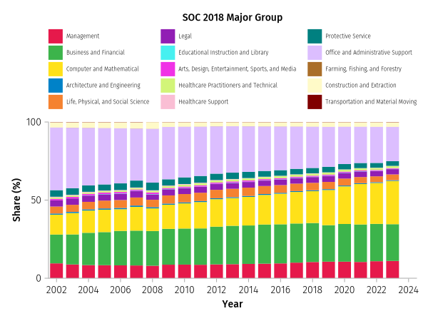

```julia
plt = data(soc_major) *
    mapping(
        :year => "Year",
        :value => "Share (%)",
        color = :soc_major => renamer(
            [
                "11" => "Management",
                "13" => "Business and Financial",
                "15" => "Computer and Mathematical",
                "17" => "Architecture and Engineering",
                "19" => "Life, Physical, and Social Science",
                "23" => "Legal",
                "25" => "Educational Instruction and Library",
                "27" => "Arts, Design, Entertainment, Sports, and Media",
                "29" => "Healthcare Practitioners and Technical",
                "31" => "Healthcare Support",
                "33" => "Protective Service",
                "43" => "Office and Administrative Support",
                "45" => "Farming, Fishing, and Forestry",
                "47" => "Construction and Extraction",
                "53" => "Transportation and Material Moving",
            ]
        ) => "SOC 2018 Major Group",
    stack = :soc_major
    ) *
    visual(BarPlot)
fig = draw(
    plt,
    scales(
        Color = (;
            palette = [
                RGBAf(230 // 255, 25 // 255, 75 // 255),
                RGBAf(60 // 255, 180 // 255, 75 // 255),
                RGBAf(255 // 255, 225 // 255, 25 // 255),
                RGBAf(0 // 255, 130 // 255, 200 // 255),
                RGBAf(245 // 255, 130 // 255, 48 // 255),
                RGBAf(145 // 255, 30 // 255, 180 // 255),
                RGBAf(70 // 255, 240 // 255, 240 // 255),
                RGBAf(240 // 255, 50 // 255, 230 // 255),
                RGBAf(210 // 255, 245 // 255, 120 // 255),
                RGBAf(250 // 255, 190 // 255, 212 // 255),
                RGBAf(0 // 255, 128 // 255, 128 // 255),
                RGBAf(220 // 255, 190 // 255, 255 // 255),
                RGBAf(170 // 255, 110 // 255, 40 // 255),
                RGBAf(255 // 255, 250 // 255, 200 // 255),
                RGBAf(128 // 255, 0 // 255, 0 // 255),
                RGBAf(170 // 255, 255 // 255, 195 // 255),
                RGBAf(128 // 255, 128 // 255, 0 // 255),
                RGBAf(255 // 255, 215 // 255, 180 // 255),
                RGBAf(0 // 255, 0 // 255, 128 // 255),
                RGBAf(128 // 255, 128 // 255, 128 // 255),
                RGBAf(255 // 255, 255 // 255, 255 // 255),
                RGBAf(0 // 255, 0 // 255, 0 // 255)
            ]
        )
    ),
    axis = (;
        xticks = 2002:2:2024,
        limits = (2001.5, 2024.5, 0, 100),
    ),
    legend = (;
        position=:top,
        nbanks = 5,
        labelsize = 8,
    ),
)
```

```julia
isdir(joinpath(DIR_PRJ, "figs")) || mkdir(joinpath(DIR_PRJ, "figs"))
save(
    joinpath(DIR_PRJ, "figs", "soc_major_contribution.eps"),
    fig
)
```

```
CairoMakie.Screen{EPS}
```

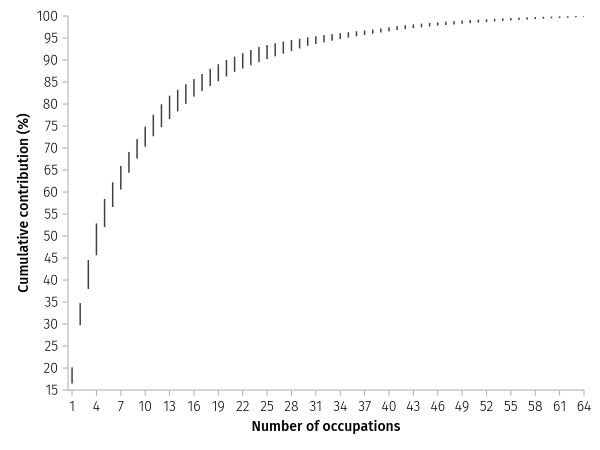

```julia
plt = data(component_cum) *
    mapping(
        :n => "Number of occupations",
        :lb => "Cumulative contribution (%)",
        :ub => "Cumulative contribution (%)",
    ) *
    visual(Rangebars)
fig = draw(
    plt,
    axis = (;
        xticks = 1:3:64,
        yticks = 15:5:100,
        limits = (0.5, 64, 15, 100)
    )
)
```

```julia
save(
    joinpath(DIR_PRJ, "figs", "cumulative_contribution.eps"),
    fig
)
```

```
CairoMakie.Screen{EPS}
```

```julia
top_occ = @chain component_contribution begin
    @arrange(year, desc(share))
    @group_by(year)
    @summarize(component, k = ~eachindex(year))
    @filter(k < 31)
    @select(component)
    @distinct
    @arrange
end
CSV.write(
    joinpath(DIR_PRJ, "data", "component_ttl.tsv"),
    (
        @chain component_ttl begin
            @left_join(@mutate(top_occ, selected = true))
            @mutate(selected = coalesce(selected, false))
        end
    ),
    delim = '\t'
)
```

```
"/workspaces/Toward-Experimental-Economic-Statistics-on-Own-Account-Data-and-Databases/data/component_ttl.tsv"
```

We explore the historical 1997-2001 period now.

```julia
industry_hist = CSV.read(
    joinpath(DIR_PRJ, "data", "oews", "timeseries_97_01.tsv"),
    DataFrame
)
```

284352×5 DataFrame

284327 rows omitted

| Row | occ_code String7 | naics Int64 | year Int64 | tot_emp Float64 | h_mean Float64 |
| --- | --- | --- | --- | --- | --- |
| 1 | 0 | 5419 | 1997 | 4.23456e5 | 13.3125 |
| 2 | 10000 | 5419 | 1997 | 23608.8 | 27.6795 |
| 3 | 13005 | 5419 | 1997 | 1064.12 | 18.8173 |
| 4 | 13011 | 5419 | 1997 | 1437.69 | 25.906 |
| 5 | 13014 | 5419 | 1997 | 1438.08 | 21.5563 |
| 6 | 15008 | 5419 | 1997 | 531.18 | 16.1714 |
| 7 | 19005 | 5419 | 1997 | 11015.5 | 29.313 |
| 8 | 19999 | 5419 | 1997 | 3624.95 | 26.192 |
| 9 | 20000 | 5419 | 1997 | 1.5542e5 | 18.0056 |
| 10 | 21100 | 5419 | 1997 | 1920.78 | 19.995 |
| 11 | 21114 | 5419 | 1997 | 1234.67 | 18.7433 |
| 12 | 21511 | 5419 | 1997 | 666.87 | 19.1762 |
| 13 | 21999 | 5419 | 1997 | 1994.32 | 18.6667 |
| ⋮ | ⋮ | ⋮ | ⋮ | ⋮ | ⋮ |
| 284341 | 53-7011 | 9030 | 2001 | 60.0 | 18.97 |
| 284342 | 53-7021 | 9030 | 2001 | 360.0 | 15.18 |
| 284343 | 53-7031 | 9030 | 2001 | 50.0 | 17.41 |
| 284344 | 53-7032 | 9030 | 2001 | 2270.0 | 14.14 |
| 284345 | 53-7041 | 9030 | 2001 | 300.0 | 17.66 |
| 284346 | 53-7051 | 9030 | 2001 | 5560.0 | 13.89 |
| 284347 | 53-7061 | 9030 | 2001 | 1080.0 | 13.7 |
| 284348 | 53-7062 | 9030 | 2001 | 33140.0 | 12.45 |
| 284349 | 53-7064 | 9030 | 2001 | 50.0 | 11.05 |
| 284350 | 53-7071 | 9030 | 2001 | 140.0 | 21.04 |
| 284351 | 53-7072 | 9030 | 2001 | 440.0 | 14.5 |
| 284352 | 53-7081 | 9030 | 2001 | 47520.0 | 13.2 |

```julia
presoc_matches = CSV.read(
    joinpath(DIR_PRJ, "data", "provided", "presoc_matched_comps.tsv"),
    DataFrame
)
```

40×2 DataFrame

15 rows omitted

| Row | occ_code Int64 | component String31 |
| --- | --- | --- |
| 1 | 13002 | 11-3031 |
| 2 | 15014 | 11-3051 |
| 3 | 21114 | 13-2011 |
| 4 | 21502 | 43-4061 |
| 5 | 21508 | 43-4111 |
| 6 | 21908 | 47-4011 |
| 7 | 21914 | 13-2081 |
| 8 | 21917 | 13-2022 \| 13-2023 |
| 9 | 22521 | 17-3031 |
| 10 | 24111 | 19-2042 |
| 11 | 24502 | 19-4021 |
| 12 | 25103 | 15-1242 \| 15-1243 |
| 13 | 25302 | 13-1081 |
| ⋮ | ⋮ | ⋮ |
| 29 | 55102 | 43-6012 |
| 30 | 55105 | 43-6013 |
| 31 | 55302 | 27-3092 |
| 32 | 55307 | 43-9022 |
| 33 | 55321 | 43-4071 |
| 34 | 55326 | 43-3061 |
| 35 | 55338 | 43-3031 |
| 36 | 55341 | 43-3051 |
| 37 | 56017 | 43-9021 |
| 38 | 56021 | 43-9021 |
| 39 | 63011 | 33-3021 |
| 40 | 63028 | 33-3021 |

```julia
industry_97_98 = @chain begin
    presoc_matches
    @mutate(occ_code = as_string(occ_code))
    @bind_rows(DataFrame(occ_code = "0", component = "00-0000"))
    @inner_join(industry_hist)
    @group_by(occ_code, naics, year)
    @summarize(
        component,
        tot_emp = tot_emp / length(unique(component)),
        h_mean
    )
    @ungroup
    @group_by(component, naics, year)
    @summarize(
        tot_emp = sum(tot_emp),
        h_mean = sum(tot_emp * h_mean) / sum(tot_emp)
    )
    @ungroup
end
```

7431×5 DataFrame

7406 rows omitted

| Row | component String | naics Int64 | year Int64 | tot_emp Float64 | h_mean Float64 |
| --- | --- | --- | --- | --- | --- |
| 1 | 00-0000 | 5419 | 1997 | 4.23456e5 | 13.3125 |
| 2 | 13-2011 | 5419 | 1997 | 1234.67 | 18.7433 |
| 3 | 29-2032 | 5419 | 1997 | 597.645 | 14.6068 |
| 4 | 29-2034 \| 29-2035 | 5419 | 1997 | 606.445 | 14.6174 |
| 5 | 43-6013 | 5419 | 1997 | 1788.79 | 8.21579 |
| 6 | 43-9022 | 5419 | 1997 | 1198.92 | 11.3537 |
| 7 | 43-3031 | 5419 | 1997 | 6078.5 | 10.3216 |
| 8 | 43-9021 | 5419 | 1997 | 1674.56 | 8.89472 |
| 9 | 00-0000 | 8129 | 1997 | 1.9054e5 | 9.5803 |
| 10 | 00-0000 | 3116 | 1997 | 4.89058e5 | 9.88812 |
| 11 | 11-3031 | 8129 | 1997 | 718.6 | 26.6779 |
| 12 | 11-3031 | 3116 | 1997 | 997.91 | 29.1406 |
| 13 | 13-2011 | 8129 | 1997 | 713.57 | 16.5256 |
| ⋮ | ⋮ | ⋮ | ⋮ | ⋮ | ⋮ |
| 7420 | 23-2011 | 9030 | 1998 | 5280.0 | 16.05 |
| 7421 | 29-2032 | 9030 | 1998 | 125.0 | 18.26 |
| 7422 | 29-2034 \| 29-2035 | 9030 | 1998 | 125.0 | 18.26 |
| 7423 | 43-6012 | 9030 | 1998 | 2400.0 | 13.7 |
| 7424 | 27-3092 | 9030 | 1998 | 9560.0 | 15.36 |
| 7425 | 43-9022 | 9030 | 1998 | 43740.0 | 11.29 |
| 7426 | 43-4071 | 9030 | 1998 | 16480.0 | 10.4 |
| 7427 | 43-3061 | 9030 | 1998 | 310.0 | 12.73 |
| 7428 | 43-3031 | 9030 | 1998 | 55980.0 | 12.34 |
| 7429 | 43-3051 | 9030 | 1998 | 8800.0 | 13.65 |
| 7430 | 43-9021 | 9030 | 1998 | 9310.0 | 11.48 |
| 7431 | 33-3021 | 9030 | 1998 | 45860.0 | 21.5269 |

```julia
occ_component_final = CSV.read(
    joinpath(DIR_PRJ, "data", "oews", "occ_component_crosswalk.tsv"),
    DataFrame
)
```

878×2 DataFrame

853 rows omitted

| Row | occ_code String7 | component String |
| --- | --- | --- |
| 1 | 11-1011 | 11-1011 |
| 2 | 11-3049 | 11-3121 |
| 3 | 11-3121 | 11-3121 |
| 4 | 17-3023 | 17-3023 |
| 5 | 17-3024 | 17-3024 |
| 6 | 17-3025 | 17-3025 |
| 7 | 17-3026 | 17-3026 |
| 8 | 17-3027 | 17-3027 |
| 9 | 17-3028 | 17-3028 \| 17-3029 |
| 10 | 17-3029 | 17-3028 \| 17-3029 |
| 11 | 17-3098 | 17-3028 \| 17-3029 |
| 12 | 17-3031 | 17-3031 |
| 13 | 19-1011 | 19-1011 |
| ⋮ | ⋮ | ⋮ |
| 867 | 53-7031 | 53-7031 |
| 868 | 53-7041 | 53-7041 |
| 869 | 53-7051 | 53-7051 |
| 870 | 53-7061 | 53-7061 |
| 871 | 53-7062 | 53-7062 |
| 872 | 53-7063 | 53-7063 |
| 873 | 53-7064 | 53-7064 |
| 874 | 53-7071 | 53-7071 |
| 875 | 53-7072 | 53-7072 |
| 876 | 53-7073 | 53-7073 |
| 877 | 53-7081 | 53-7081 |
| 878 | 53-7121 | 53-7121 |

```julia
industry_99_01 = @chain industry_hist begin
    @filter(year ∈ 1999:2001)
    @inner_join(occ_component_final)
    @group_by(occ_code, naics, year)
    @summarize(
        component,
        tot_emp = tot_emp / length(unique(component)),
        h_mean
    )
    @ungroup
    @group_by(component, naics, year)
    @summarize(
        tot_emp = sum(tot_emp),
        h_mean = sum(tot_emp * h_mean) / sum(tot_emp)
    )
    @ungroup
end
```

139223×5 DataFrame

139198 rows omitted

| Row | component String | naics Int64 | year Int64 | tot_emp Float64 | h_mean Float64 |
| --- | --- | --- | --- | --- | --- |
| 1 | 11-1011 | 5419 | 1999 | 3118.29 | 47.0818 |
| 2 | 11-1021 | 5419 | 1999 | 10464.4 | 28.6281 |
| 3 | 11-9111 | 5419 | 1999 | 979.47 | 23.6695 |
| 4 | 13-2011 | 5419 | 1999 | 1482.2 | 19.9672 |
| 5 | 29-1131 | 5419 | 1999 | 36767.3 | 31.9597 |
| 6 | 29-2011 \| 29-2012 | 5419 | 1999 | 1589.29 | 13.1411 |
| 7 | 29-2056 | 5419 | 1999 | 44241.6 | 10.1709 |
| 8 | 31-9096 | 5419 | 1999 | 46615.3 | 7.68059 |
| 9 | 37-2011 | 5419 | 1999 | 2825.36 | 7.65118 |
| 10 | 37-2012 | 5419 | 1999 | 302.85 | 7.62302 |
| 11 | 39-1014 | 5419 | 1999 | 114.96 | 10.9857 |
| 12 | 39-2021 | 5419 | 1999 | 20098.0 | 7.42893 |
| 13 | 43-1011 | 5419 | 1999 | 7674.61 | 13.6288 |
| ⋮ | ⋮ | ⋮ | ⋮ | ⋮ | ⋮ |
| 139212 | 53-7011 | 9030 | 2001 | 60.0 | 18.97 |
| 139213 | 53-7021 | 9030 | 2001 | 360.0 | 15.18 |
| 139214 | 53-7031 | 9030 | 2001 | 50.0 | 17.41 |
| 139215 | 47-5022 | 9030 | 2001 | 2270.0 | 14.14 |
| 139216 | 53-7041 | 9030 | 2001 | 300.0 | 17.66 |
| 139217 | 53-7051 | 9030 | 2001 | 5560.0 | 13.89 |
| 139218 | 53-7061 | 9030 | 2001 | 1080.0 | 13.7 |
| 139219 | 53-7062 | 9030 | 2001 | 33140.0 | 12.45 |
| 139220 | 53-7064 | 9030 | 2001 | 50.0 | 11.05 |
| 139221 | 53-7071 | 9030 | 2001 | 140.0 | 21.04 |
| 139222 | 53-7072 | 9030 | 2001 | 440.0 | 14.5 |
| 139223 | 53-7081 | 9030 | 2001 | 47520.0 | 13.2 |

```julia
hist_naics = @chain industry_hist begin
    @bind_rows(industry_99_01)
    @select(histnaics = naics, naics)
    @distinct
    @left_join(@select(naics2ipa, naics, account))
    @mutate(naics = case_when(
        ismissing(account) => naics ÷ 10 * 10,
        true => naics
        )
    )
    @select(-account)
    @left_join(@select(naics2ipa, naics, account))
    @distinct
    @select(naics = histnaics, account)
end
```

280×2 DataFrame

255 rows omitted

| Row | naics Int64 | account String7? |
| --- | --- | --- |
| 1 | 5419 | 5412OP |
| 2 | 5413 | 5412OP |
| 3 | 5510 | 55 |
| 4 | 2130 | 213 |
| 5 | 2110 | 211 |
| 6 | 5412 | 5412OP |
| 7 | 5417 | 5412OP |
| 8 | 4930 | 493 |
| 9 | 5415 | 5415 |
| 10 | 3363 | 3361MV |
| 11 | 3230 | 323 |
| 12 | 5160 | 511 |
| 13 | 3361 | 3361MV |
| ⋮ | ⋮ | ⋮ |
| 269 | 6114 | 61 |
| 270 | 6117 | 61 |
| 271 | 6241 | 624 |
| 272 | 6242 | 624 |
| 273 | 6243 | 624 |
| 274 | 6244 | 624 |
| 275 | 6239 | 623 |
| 276 | 8133 | 81 |
| 277 | 8134 | 81 |
| 278 | 8131 | 81 |
| 279 | 5611 | 561 |
| 280 | 5612 | 561 |

```julia
timeseries_97_01_acc = @chain industry_97_98 begin
    @bind_rows(industry_99_01)
    @inner_join(hist_naics)
    dropmissing!
    @group_by(component, account, year)
    @summarize(
        tot_emp = sum(tot_emp),
        h_mean = sum(tot_emp * h_mean) / sum(tot_emp)
    )
    @ungroup
end
```

47539×5 DataFrame

47514 rows omitted

| Row | component String | account String7 | year Int64 | tot_emp Float64 | h_mean Float64 |
| --- | --- | --- | --- | --- | --- |
| 1 | 00-0000 | 5412OP | 1997 | 3.89204e6 | 18.0627 |
| 2 | 13-2011 | 5412OP | 1997 | 2.32869e5 | 21.0346 |
| 3 | 29-2032 | 5412OP | 1997 | 4065.6 | 15.1479 |
| 4 | 29-2034 \| 29-2035 | 5412OP | 1997 | 4205.73 | 15.141 |
| 5 | 43-6013 | 5412OP | 1997 | 2125.35 | 8.67521 |
| 6 | 43-9022 | 5412OP | 1997 | 29888.3 | 11.8816 |
| 7 | 43-3031 | 5412OP | 1997 | 1.13244e5 | 12.1956 |
| 8 | 43-9021 | 5412OP | 1997 | 34301.4 | 9.48009 |
| 9 | 00-0000 | 81 | 1997 | 3.53153e6 | 11.4955 |
| 10 | 00-0000 | 311FT | 1997 | 1.76401e6 | 11.8639 |
| 11 | 11-3031 | 81 | 1997 | 34470.9 | 20.7712 |
| 12 | 11-3031 | 311FT | 1997 | 6250.44 | 31.2073 |
| 13 | 13-2011 | 81 | 1997 | 16262.0 | 16.11 |
| ⋮ | ⋮ | ⋮ | ⋮ | ⋮ | ⋮ |
| 47528 | 53-2022 | GSL | 2001 | 800.0 | 16.41 |
| 47529 | 53-3011 | GSL | 2001 | 3000.0 | 10.25 |
| 47530 | 53-3052 | GSL | 2001 | 92750.0 | 15.98 |
| 47531 | 53-3031 | GSL | 2001 | 390.0 | 13.26 |
| 47532 | 53-6021 | GSL | 2001 | 2370.0 | 10.43 |
| 47533 | 53-7011 | GSL | 2001 | 60.0 | 18.97 |
| 47534 | 53-7041 | GSL | 2001 | 300.0 | 17.66 |
| 47535 | 53-7061 | GSL | 2001 | 1080.0 | 13.7 |
| 47536 | 53-7064 | GSL | 2001 | 50.0 | 11.05 |
| 47537 | 53-7071 | GSL | 2001 | 140.0 | 21.04 |
| 47538 | 53-7072 | GSL | 2001 | 440.0 | 14.5 |
| 47539 | 53-7081 | GSL | 2001 | 47520.0 | 13.2 |

```julia
timeseries_97_98_share = @chain timeseries_97_01_acc begin
    @filter((year ∈ 1997:1998) & (component == "00-0000"))
    @group_by(account, year)
    @summarize(
        tot_emp_den = tot_emp,
        payroll = sum(tot_emp * h_mean)
    )
    @ungroup
    @inner_join(timeseries_97_01_acc)
    @select(
        component,
        account,
        year,
        tot_emp = tot_emp / tot_emp_den,
        share = tot_emp * h_mean / payroll
    )
    @filter(component ≠ "00-0000")
    @arrange
end
```

2043×5 DataFrame

2018 rows omitted

| Row | component String | account String7 | year Int64 | tot_emp Float64 | share Float64 |
| --- | --- | --- | --- | --- | --- |
| 1 | 11-3031 | 113FF | 1997 | 0.000738371 | 0.0017407 |
| 2 | 11-3031 | 113FF | 1998 | 0.000623675 | 0.001459 |
| 3 | 11-3031 | 211 | 1997 | 0.011935 | 0.019392 |
| 4 | 11-3031 | 211 | 1998 | 0.0127329 | 0.0205438 |
| 5 | 11-3031 | 212 | 1997 | 0.00637793 | 0.01199 |
| 6 | 11-3031 | 212 | 1998 | 0.00649361 | 0.0122231 |
| 7 | 11-3031 | 213 | 1997 | 0.00568446 | 0.0127389 |
| 8 | 11-3031 | 213 | 1998 | 0.00593777 | 0.0126345 |
| 9 | 11-3031 | 22 | 1997 | 0.00542958 | 0.00846464 |
| 10 | 11-3031 | 22 | 1998 | 0.00528722 | 0.008213 |
| 11 | 11-3031 | 23 | 1997 | 0.00712906 | 0.0115513 |
| 12 | 11-3031 | 23 | 1998 | 0.0065862 | 0.0108098 |
| 13 | 11-3031 | 311FT | 1997 | 0.00354331 | 0.0093205 |
| ⋮ | ⋮ | ⋮ | ⋮ | ⋮ | ⋮ |
| 2032 | 47-4011 | 561 | 1998 | 0.000120154 | 0.000215094 |
| 2033 | 47-4011 | 562 | 1997 | 9.88357e-6 | 1.19096e-5 |
| 2034 | 47-4011 | 61 | 1997 | 8.36977e-5 | 0.000105728 |
| 2035 | 47-4011 | 61 | 1998 | 6.18399e-5 | 7.75016e-5 |
| 2036 | 47-4011 | 711AS | 1997 | 5.64088e-6 | 6.74459e-6 |
| 2037 | 47-4011 | 711AS | 1998 | 5.10766e-6 | 6.12849e-6 |
| 2038 | 47-4011 | 81 | 1997 | 1.65113e-5 | 2.63788e-5 |
| 2039 | 47-4011 | 81 | 1998 | 2.72033e-5 | 4.01221e-5 |
| 2040 | 47-4011 | GF | 1997 | 0.00101395 | 0.00104262 |
| 2041 | 47-4011 | GF | 1998 | 0.000960114 | 0.00101878 |
| 2042 | 47-4011 | GSL | 1997 | 0.00578639 | 0.00680859 |
| 2043 | 47-4011 | GSL | 1998 | 0.0059809 | 0.00699275 |

```julia
timeseries_99_01_share = @chain timeseries_97_01_acc begin
    @filter(year ∈ 1999:2001)
    @group_by(account, year)
    @summarize(
        tot_emp_den = sum(tot_emp),
        payroll = sum(tot_emp * h_mean)
    )
    @ungroup
    @inner_join(
        @filter(timeseries_97_01_acc, year ∈ 1999:2001)
    )
    @select(
        component,
        account,
        year,
        tot_emp = tot_emp / tot_emp_den,
        share = tot_emp * h_mean / payroll
    )
end
```

45364×5 DataFrame

45339 rows omitted

| Row | component String | account String7 | year Int64 | tot_emp Float64 | share Float64 |
| --- | --- | --- | --- | --- | --- |
| 1 | 11-1011 | 5412OP | 1999 | 0.0165145 | 0.0436777 |
| 2 | 11-1021 | 5412OP | 1999 | 0.0356435 | 0.0694753 |
| 3 | 11-9111 | 5412OP | 1999 | 0.00142236 | 0.00205295 |
| 4 | 13-2011 | 5412OP | 1999 | 0.0660546 | 0.0764971 |
| 5 | 29-1131 | 5412OP | 1999 | 0.010153 | 0.0161934 |
| 6 | 29-2011 \| 29-2012 | 5412OP | 1999 | 0.00166922 | 0.00124611 |
| 7 | 29-2056 | 5412OP | 1999 | 0.0122155 | 0.00620315 |
| 8 | 31-9096 | 5412OP | 1999 | 0.0135654 | 0.00534804 |
| 9 | 37-2011 | 5412OP | 1999 | 0.00467708 | 0.00209447 |
| 10 | 37-2012 | 5412OP | 1999 | 0.00186971 | 0.000702122 |
| 11 | 39-1014 | 5412OP | 1999 | 0.000341465 | 0.000252658 |
| 12 | 39-2021 | 5412OP | 1999 | 0.00562392 | 0.00209645 |
| 13 | 43-1011 | 5412OP | 1999 | 0.0162566 | 0.0141415 |
| ⋮ | ⋮ | ⋮ | ⋮ | ⋮ | ⋮ |
| 45353 | 53-2022 | GSL | 2001 | 0.000121807 | 0.000112586 |
| 45354 | 53-3011 | GSL | 2001 | 0.000456777 | 0.000263712 |
| 45355 | 53-3052 | GSL | 2001 | 0.014122 | 0.0127109 |
| 45356 | 53-3031 | GSL | 2001 | 5.93811e-5 | 4.43499e-5 |
| 45357 | 53-6021 | GSL | 2001 | 0.000360854 | 0.000211991 |
| 45358 | 53-7011 | GSL | 2001 | 9.13555e-6 | 9.7612e-6 |
| 45359 | 53-7041 | GSL | 2001 | 4.56777e-5 | 4.54356e-5 |
| 45360 | 53-7061 | GSL | 2001 | 0.00016444 | 0.00012689 |
| 45361 | 53-7064 | GSL | 2001 | 7.61296e-6 | 4.73824e-6 |
| 45362 | 53-7071 | GSL | 2001 | 2.13163e-5 | 2.52615e-5 |
| 45363 | 53-7072 | GSL | 2001 | 6.6994e-5 | 5.47149e-5 |
| 45364 | 53-7081 | GSL | 2001 | 0.00723535 | 0.00537942 |

```julia
timeseries_97_98_share = @chain timeseries_99_01_share begin
    @filter(year == 1999)
    @select(-year)
    crossjoin(_, DataFrame(year = 1997:1998))
end
```

26916×5 DataFrame

26891 rows omitted

| Row | component String | account String7 | tot_emp Float64 | share Float64 | year Int64 |
| --- | --- | --- | --- | --- | --- |
| 1 | 11-1011 | 5412OP | 0.0165145 | 0.0436777 | 1997 |
| 2 | 11-1011 | 5412OP | 0.0165145 | 0.0436777 | 1998 |
| 3 | 11-1021 | 5412OP | 0.0356435 | 0.0694753 | 1997 |
| 4 | 11-1021 | 5412OP | 0.0356435 | 0.0694753 | 1998 |
| 5 | 11-9111 | 5412OP | 0.00142236 | 0.00205295 | 1997 |
| 6 | 11-9111 | 5412OP | 0.00142236 | 0.00205295 | 1998 |
| 7 | 13-2011 | 5412OP | 0.0660546 | 0.0764971 | 1997 |
| 8 | 13-2011 | 5412OP | 0.0660546 | 0.0764971 | 1998 |
| 9 | 29-1131 | 5412OP | 0.010153 | 0.0161934 | 1997 |
| 10 | 29-1131 | 5412OP | 0.010153 | 0.0161934 | 1998 |
| 11 | 29-2011 \| 29-2012 | 5412OP | 0.00166922 | 0.00124611 | 1997 |
| 12 | 29-2011 \| 29-2012 | 5412OP | 0.00166922 | 0.00124611 | 1998 |
| 13 | 29-2056 | 5412OP | 0.0122155 | 0.00620315 | 1997 |
| ⋮ | ⋮ | ⋮ | ⋮ | ⋮ | ⋮ |
| 26905 | 47-5022 | GSL | 0.000207839 | 0.000171532 | 1997 |
| 26906 | 47-5022 | GSL | 0.000207839 | 0.000171532 | 1998 |
| 26907 | 53-7051 | GSL | 0.000865454 | 0.000661245 | 1997 |
| 26908 | 53-7051 | GSL | 0.000865454 | 0.000661245 | 1998 |
| 26909 | 53-7061 | GSL | 0.000118533 | 8.33745e-5 | 1997 |
| 26910 | 53-7061 | GSL | 0.000118533 | 8.33745e-5 | 1998 |
| 26911 | 53-7071 | GSL | 3.57223e-5 | 4.19141e-5 | 1997 |
| 26912 | 53-7071 | GSL | 3.57223e-5 | 4.19141e-5 | 1998 |
| 26913 | 53-7072 | GSL | 8.44345e-5 | 6.91677e-5 | 1997 |
| 26914 | 53-7072 | GSL | 8.44345e-5 | 6.91677e-5 | 1998 |
| 26915 | 53-7121 | GSL | 1.46137e-5 | 1.03686e-5 | 1997 |
| 26916 | 53-7121 | GSL | 1.46137e-5 | 1.03686e-5 | 1998 |

```julia
data_payroll_hist = @chain timeseries_97_98_share begin
    @bind_rows(timeseries_99_01_share)
    @inner_join(
        @select(
            component_rates,
            component,
            refined
        )
    )
    @select(
        account,
        component,
        year,
        tot_emp = tot_emp * refined / 100,
        share = share * refined / 100
    )
    @filter(share > 0)
    @inner_join(
        @chain ilpa_labor begin
            @mutate(
                account = case_when(
                    contains(account, "GF") => "GF",
                    contains(account, "GSL") => "GSL",
                    account == "622" => "622HO",
                    true => account
                )
            )
            @group_by(year, account)
            @summarize(labor = sum(value))
            @ungroup
        end
    )
    @select(
        account,
        component,
        year,
        tot_emp,
        labor = labor * share
    )
end
```

7276×5 DataFrame

7251 rows omitted

| Row | account String7 | component String | year Int64 | tot_emp Float64 | labor Float64 |
| --- | --- | --- | --- | --- | --- |
| 1 | 5412OP | 13-2011 | 1997 | 0.0198164 | 5927.1 |
| 2 | 5412OP | 13-2011 | 1998 | 0.0198164 | 6447.67 |
| 3 | 5412OP | 29-2056 | 1997 | 0.00122155 | 160.209 |
| 4 | 5412OP | 29-2056 | 1998 | 0.00122155 | 174.281 |
| 5 | 5412OP | 43-3031 | 1997 | 0.00608484 | 997.709 |
| 6 | 5412OP | 43-3031 | 1998 | 0.00608484 | 1085.34 |
| 7 | 5412OP | 43-3061 | 1997 | 8.98942e-5 | 16.4019 |
| 8 | 5412OP | 43-3061 | 1998 | 8.98942e-5 | 17.8425 |
| 9 | 5412OP | 43-6013 | 1997 | 0.000355743 | 43.3451 |
| 10 | 5412OP | 43-6013 | 1998 | 0.000355743 | 47.1521 |
| 11 | 5412OP | 43-9021 | 1997 | 0.0134475 | 1740.95 |
| 12 | 5412OP | 43-9021 | 1998 | 0.0134475 | 1893.85 |
| 13 | 81 | 11-3031 | 1997 | 0.000894047 | 331.438 |
| ⋮ | ⋮ | ⋮ | ⋮ | ⋮ | ⋮ |
| 7265 | GSL | 43-6012 | 2001 | 0.000672376 | 557.883 |
| 7266 | GSL | 43-6013 | 2001 | 2.96905e-5 | 19.5855 |
| 7267 | GSL | 43-9021 | 2001 | 0.00257485 | 1579.01 |
| 7268 | GSL | 43-9022 | 2001 | 0.00223334 | 1369.66 |
| 7269 | GSL | 43-9041 | 2001 | 3.38015e-5 | 25.3556 |
| 7270 | GSL | 45-2011 | 2001 | 6.85166e-5 | 52.1148 |
| 7271 | GSL | 47-4011 | 2001 | 0.0040909 | 3859.09 |
| 7272 | GSL | 53-6041 | 2001 | 0.000175098 | 139.009 |
| 7273 | GSL | 19-4051 | 2001 | 1.37033e-6 | 1.79819 |
| 7274 | GSL | 29-2032 | 2001 | 2.13163e-6 | 2.29369 |
| 7275 | GSL | 43-5041 | 2001 | 0.000509992 | 316.605 |
| 7276 | GSL | 53-2022 | 2001 | 1.82711e-5 | 14.3071 |

```julia
data_payroll_hist_ = @chain timeseries_97_98_share begin
    @bind_rows(timeseries_99_01_share)
    @filter(year ∈ 1997:2001)
    @select(-tot_emp)
    @pivot_wider(names_from = year, values_from = share)
end
```

17017×7 DataFrame

16992 rows omitted

| Row | component String | account String7 | 1997 Float64? | 1998 Float64? | 1999 Float64? | 2000 Float64? | 2001 Float64? |
| --- | --- | --- | --- | --- | --- | --- | --- |
| 1 | 11-1011 | 5412OP | 0.0436777 | 0.0436777 | 0.0436777 | 0.0329722 | 0.0276148 |
| 2 | 11-1021 | 5412OP | 0.0694753 | 0.0694753 | 0.0694753 | 0.0702702 | 0.0650987 |
| 3 | 11-9111 | 5412OP | 0.00205295 | 0.00205295 | 0.00205295 | 0.00210803 | 0.00210966 |
| 4 | 13-2011 | 5412OP | 0.0764971 | 0.0764971 | 0.0764971 | 0.0743699 | 0.0809363 |
| 5 | 29-1131 | 5412OP | 0.0161934 | 0.0161934 | 0.0161934 | 0.0152696 | 0.0150545 |
| 6 | 29-2011 \| 29-2012 | 5412OP | 0.00124611 | 0.00124611 | 0.00124611 | 0.00132736 | 0.00201904 |
| 7 | 29-2056 | 5412OP | 0.00620315 | 0.00620315 | 0.00620315 | 0.00605771 | 0.0062364 |
| 8 | 31-9096 | 5412OP | 0.00534804 | 0.00534804 | 0.00534804 | 0.00512587 | 0.00556363 |
| 9 | 37-2011 | 5412OP | 0.00209447 | 0.00209447 | 0.00209447 | 0.00195524 | 0.00223715 |
| 10 | 37-2012 | 5412OP | 0.000702122 | 0.000702122 | 0.000702122 | 0.000640302 | 0.000715519 |
| 11 | 39-1014 | 5412OP | 0.000252658 | 0.000252658 | 0.000252658 | 0.000249781 | 0.000256898 |
| 12 | 39-2021 | 5412OP | 0.00209645 | 0.00209645 | 0.00209645 | 0.00212466 | 0.00209687 |
| 13 | 43-1011 | 5412OP | 0.0141415 | 0.0141415 | 0.0141415 | 0.015921 | 0.0161788 |
| ⋮ | ⋮ | ⋮ | ⋮ | ⋮ | ⋮ | ⋮ | ⋮ |
| 17006 | 53-2022 | GF | missing | missing | missing | missing | 0.000106307 |
| 17007 | 29-1011 | GSL | missing | missing | missing | missing | 9.31782e-6 |
| 17008 | 31-9011 | GSL | missing | missing | missing | missing | 4.7957e-6 |
| 17009 | 41-3031 | GSL | missing | missing | missing | missing | 3.21386e-5 |
| 17010 | 51-2022 \| 51-2023 | GSL | missing | missing | missing | missing | 3.75114e-6 |
| 17011 | 17-2031 | GSL | missing | missing | missing | missing | 1.00982e-5 |
| 17012 | 27-2031 | GSL | missing | missing | missing | missing | 5.28968e-6 |
| 17013 | 39-6011 | GSL | missing | missing | missing | missing | 3.75629e-6 |
| 17014 | 47-2022 | GSL | missing | missing | missing | missing | 8.14634e-6 |
| 17015 | 47-5081 | GSL | missing | missing | missing | missing | 3.94333e-5 |
| 17016 | 51-9021 | GSL | missing | missing | missing | missing | 3.82858e-5 |
| 17017 | 51-9031 | GSL | missing | missing | missing | missing | 1.83904e-5 |

# Full production cost adjustment factor

We use the representative industries NAICS 518-519 (514) and NAICS 5415.

```julia
fpcaf = @chain CSV.read(
    joinpath(DIR_PRJ, "data", "fpcaf.tsv"),
    DataFrame
) begin
    @bind_rows(
        _,
        DataFrame(
            year = last(_.year) + 1,
            fpcaf = last(_.fpcaf)
        )
    )
    @distinct
end
```

37×2 DataFrame

12 rows omitted

| Row | year Int64 | fpcaf Float64 |
| --- | --- | --- |
| 1 | 1988 | 1.47557 |
| 2 | 1989 | 1.50504 |
| 3 | 1990 | 1.50011 |
| 4 | 1991 | 1.47971 |
| 5 | 1992 | 1.45119 |
| 6 | 1993 | 1.4532 |
| 7 | 1994 | 1.46537 |
| 8 | 1995 | 1.48213 |
| 9 | 1996 | 1.49394 |
| 10 | 1997 | 1.51966 |
| 11 | 1998 | 1.55748 |
| 12 | 1999 | 1.60223 |
| 13 | 2000 | 1.66654 |
| ⋮ | ⋮ | ⋮ |
| 26 | 2013 | 2.04732 |
| 27 | 2014 | 2.08273 |
| 28 | 2015 | 2.10802 |
| 29 | 2016 | 2.1399 |
| 30 | 2017 | 2.163 |
| 31 | 2018 | 2.17948 |
| 32 | 2019 | 2.18775 |
| 33 | 2020 | 2.186 |
| 34 | 2021 | 2.17651 |
| 35 | 2022 | 2.18418 |
| 36 | 2023 | 2.19439 |
| 37 | 2024 | 2.19439 |

The fpcafs use a 10-years lagged simple trimmed moving average to smooth the changes.

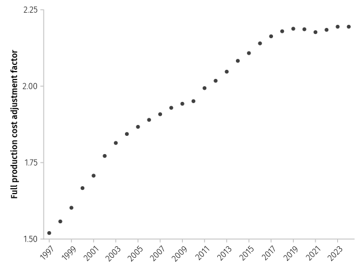

```julia
plt = data(fpcaf) *
    mapping(
        :year => "",
        :fpcaf => "Full production cost adjustment factor"
    ) *
    visual(Scatter)
fig = draw(
    plt,
    axis = (;
        xticks = 1997:2:2024,
        yticks = 1.5:0.25:2.5,
        xticklabelrotation = π / 4,
        limits = (1996.5, 2024.5, 1.5, 2.25),
    ),
)
save(
    joinpath(DIR_PRJ, "figs", "fpcaf.eps"),
    fig
)
fig
```

# Nominal investment

```julia
gfcf = @chain data_payroll begin
    @pivot_wider(
        names_from = variable,
        values_from = value
    )
    @rename(tot_emp = employment_share)
    @bind_rows(data_payroll_hist)
    @inner_join(@select(fpcaf, year, fpcaf))
    @select(
        account,
        component,
        year,
        tot_emp,
        labor,
        gfcf = labor * fpcaf
    )
    @arrange
end
```

38263×6 DataFrame

38238 rows omitted

| Row | account String7 | component String | year Int64 | tot_emp Float64? | labor Float64? | gfcf Float64 |
| --- | --- | --- | --- | --- | --- | --- |
| 1 | 113FF | 11-3031 | 1997 | 0.00062834 | 11.4687 | 17.4285 |
| 2 | 113FF | 11-3031 | 1998 | 0.00062834 | 11.4334 | 17.8073 |
| 3 | 113FF | 11-3031 | 1999 | 0.00062834 | 12.5004 | 20.0285 |
| 4 | 113FF | 11-3031 | 2000 | 0.000386986 | 9.69684 | 16.1601 |
| 5 | 113FF | 11-3031 | 2001 | 0.000272562 | 6.76043 | 11.5413 |
| 6 | 113FF | 11-3031 | 2002 | 0.000194757 | 8.12939 | 14.4035 |
| 7 | 113FF | 11-3031 | 2003 | 0.000126561 | 6.69631 | 12.1482 |
| 8 | 113FF | 11-3031 | 2004 | 0.000114501 | 7.32909 | 13.5111 |
| 9 | 113FF | 11-3031 | 2005 | 9.28136e-5 | 5.46186 | 10.1969 |
| 10 | 113FF | 11-3031 | 2006 | 0.000204511 | 10.6761 | 20.1746 |
| 11 | 113FF | 11-3031 | 2007 | 8.50478e-5 | 6.18529 | 11.8025 |
| 12 | 113FF | 11-3031 | 2008 | 8.74798e-5 | 6.87281 | 13.2585 |
| 13 | 113FF | 11-3031 | 2009 | 8.48074e-5 | 6.93291 | 13.4664 |
| ⋮ | ⋮ | ⋮ | ⋮ | ⋮ | ⋮ | ⋮ |
| 38252 | GSL | 53-6041 | 2012 | 0.000102119 | 121.787 | 245.711 |
| 38253 | GSL | 53-6041 | 2013 | 0.000101906 | 127.057 | 260.126 |
| 38254 | GSL | 53-6041 | 2014 | 0.000104769 | 139.046 | 289.596 |
| 38255 | GSL | 53-6041 | 2015 | 0.00010626 | 145.713 | 307.166 |
| 38256 | GSL | 53-6041 | 2016 | 9.9489e-5 | 138.144 | 295.614 |
| 38257 | GSL | 53-6041 | 2017 | 0.000107476 | 150.144 | 324.762 |
| 38258 | GSL | 53-6041 | 2018 | 0.000108556 | 159.584 | 347.809 |
| 38259 | GSL | 53-6041 | 2019 | 0.000115891 | 175.945 | 384.924 |
| 38260 | GSL | 53-6041 | 2020 | 0.000119434 | 180.167 | 393.846 |
| 38261 | GSL | 53-6041 | 2021 | 0.000127614 | 192.663 | 419.332 |
| 38262 | GSL | 53-6041 | 2022 | 0.000112251 | 177.168 | 386.966 |
| 38263 | GSL | 53-6041 | 2023 | 0.000124541 | 199.523 | 437.83 |

We save the detailed table of the investment and the unit of labor.

```julia
CSV.write(
    joinpath(DIR_PRJ, "data", "gfcf.tsv"),
    gfcf,
    delim = '\t'
)
```

```
"/workspaces/Toward-Experimental-Economic-Statistics-on-Own-Account-Data-and-Databases/data/gfcf.tsv"
```

## References

Bureau of Labor Statistics. 2024. *Occupational Outlook Handbook*. https://www.bls.gov/ooh.

U.S. Department of Labor. 2024. *O*NET 28.3 Database*. https://www.onetcenter.org/db_releases.html.